# Reproducible Research: Peer Assessment 1

Hal Peterson

## Preamble

Load useful libraries.

```r
library (plyr)
library (lattice)
```

## Loading and preprocessing the data

Assignment data set is included in the Git repository, forked from https://github.com/rdpeng/RepData_PeerAssessment1, in the file activity.zip. In my repository I’ve manually unpacked that to activity.csv. Load it:

```r
acts <- read.csv ('activity.csv')
```

The result is usable as is.

## What is mean total number of steps taken per day?

Plyr is a convenient tool to add up the steps taken in each day.

```r
spd <- ddply (acts,
              .(date),
              summarize,
              stepSum=sum (steps, na.rm=TRUE))
```

Display the result.

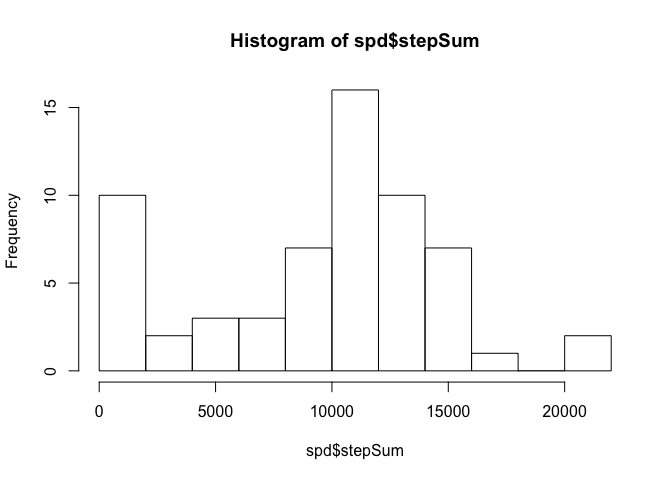

```r
hist (spd$stepSum, breaks=13)
```

The subject took a mean of 9354.2295082 steps and median of 10395 steps per day.

## What is the average daily activity pattern?

Once again, Plyr is our friend.

```r
spi <- ddply (acts,
              .(interval),
              summarize,
              stepMean = mean(steps, na.rm=TRUE))
```

Display it:

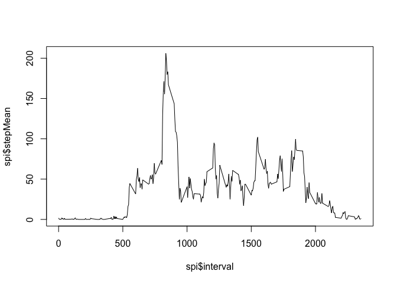

```r
plot (spi$interval, spi$stepMean, type='l')
```

The busiest interval of the subject’s day, on average was 835.

## Imputing missing values

```r
which <- is.na (acts$steps)
```

The data set comprises many missing step count values: a total of 2304, or 13.1147541 percent of the total.

We use a two-stage strategy for imputing missing values to the data. First, we replace an NA at interval `i` with the mean number of steps in that interval over the rest of the data set. Unfortunately, many intervals are NA over the entire series; for those we impute the grand mean over all non-NA data.

```r
fixie <- acts
fixie$steps[which] <-
  spi$stepMean[spi$interval == fixie$interval[which]]
fixie$steps[is.na (fixie$steps)] <-
  mean (acts$steps, na.rm=TRUE)
```

Fixed! Did it change anything? Here’s the new histogram:

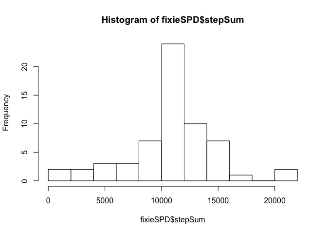

```r
fixieSPD <- ddply (fixie,
                   .(date),
                   summarize,
                   stepSum=sum (steps))
hist (fixieSPD$stepSum,
      breaks=13)
```

## Are there differences in activity patterns between weekdays and weekends?

First, let’s distinguish weekdays from weekends.

```r
wd <- weekdays (as.Date (fixie$date))
fixie$dayTypes <- factor (wd,
                          levels <- c ('weekday', 'weekend'))
fixie$dayTypes[] <- 'weekday'
fixie$dayTypes[wd %in% c ('Saturday', 'Sunday')] <- 'weekend'
```

Now, compute summaries and plot the two:

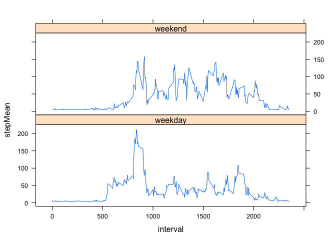

```r
spi <- ddply (fixie,
              .(interval, dayTypes),
              summarize,
              stepMean = mean(steps, na.rm=TRUE))
xyplot (stepMean ~ interval | dayTypes,
        data=spi,
        type='l',
        layout=c (1, 2))
```

Conclusion: the subjects slept later on weekends. Good on ’em!